# Notebook for the Python lesson at Weill Cornell Medical College

(Time 3 hours 15 minutes)

### Python jargon

- "Python" refers to the programming language itself. You use Python to write source code and give instructions to your computer.
  - Python has two dialects: Python 2 (we're using that) and Python 3 (newer, but not sticking yet)
  - Python has only a few words (keywords), like 20~ish. `print` is a keyword (in Python 2, not in 3)
- "python" refers to the interpreter, a program that translates source code into actual instructions to the machine
  - you call the interpreter typing `python` in your terminal
  - working in the interpreter can be hard (ugly and error-prone)
- "ipython" is a wrapper around the interpreter, which adds some nice features, but you still have to work in a command line interface
  - you call the "ipython" typing `ipython` in your terminal
- "ipython notebook" is another "wrapper" that puts everything into your browser
  - you call the "ipython notebook" (now called "jupyter") typing `ipython notebook` in your terminal

### A simple command (actually is called a statement) in Python

```python
print "Hello"
```

```
Hello
```

## Names and objects

```python
weight_kg = 55
```

```python
weight_kg
```

```
55
```

```python
print weight_kg
```

```
55
```

```python
print "Weight in pounds is ", 2.2 * weight_kg
```

```
Weight in pounds is  121.0
```

```python
weight_lb = 2.2 * weight_kg
```

```python
print weight_lb
```

```
121.0
```

```python
weight_kg = 100
```

```python
print weight_kg
```

```
100
```

```python
print weight_lb
```

```
121.0
```

## Loading a library of functions (is called a module) from your hard drive into this program

Numpy is a library for some math in Python

```python
import numpy
```

We creating a new name (`data`) to store the result of calling a function in the numpy module that reads text files (`numpy.loadtxt`)

```python
data = numpy.loadtxt(fname="data/inflammation-01.csv", delimiter=',')
```

```python
print data
```

```
[[ 0.  0.  1. ...,  3.  0.  0.]
 [ 0.  1.  2. ...,  1.  0.  1.]
 [ 0.  1.  1. ...,  2.  1.  1.]
 ...,
 [ 0.  1.  1. ...,  1.  1.  1.]
 [ 0.  0.  0. ...,  0.  2.  0.]
 [ 0.  0.  1. ...,  1.  1.  0.]]
```

`type` is a Python built-in function (is loaded by default when you start any interpreter) which tells you the kind of object referred by a name.

Object is the generic concept for "things" in Python, everything is an object. Objects represent how the "thing" is stored in the computer memory, for example they have instructions on how your computer reads the object from the memory, so you may get an error if you are trying to process an object as the wrong kind. More importantly for you, objects have functions associated to them (called methods). Each type of object may have its own methods.

```python
print type(data)
```

```
<type 'numpy.ndarray'>
```

```python
print type(weight_lb)
```

```
<type 'float'>
```

```python
data.shape
```

```
(60, 40)
```

```python
weight_lb.shape
```

```
---------------------------------------------------------------------------
AttributeError                            Traceback (most recent call last)
<ipython-input-20-18bfedc41582> in <module>()
----> 1 weight_lb.shape

AttributeError: 'float' object has no attribute 'shape'
```

## Indexing and slicing

```python
data[3:4, 20]
```

[output not shown]

```python
data[:4, 30:]
```

[output not shown]

```python
data[30, 20]
```

```
13.0
```

```python
sample = data[4:8, 1:3]
```

```python
print sample
```

```
[[ 1.  1.]
 [ 0.  1.]
 [ 0.  2.]
 [ 0.  1.]]
```

```python
### Operators and methods for Numpy arrays
```

```python
double_sample = 2 * sample
```

```python
print double_sample
```

```
[[ 2.  2.]
 [ 0.  2.]
 [ 0.  4.]
 [ 0.  2.]]
```

```python
data.mean()
```

```
6.1487499999999997
```

```python
data.max()
```

```
20.0
```

```python
data.min()
```

```
0.0
```

Pause and reflect on the amount of work that your computer has done when you called any of this methods. This is called high-level programming language and means you don't need to know much about how your computer does its thing.

Slicing a numpy array gives you another numpy array (nice, we still have all methods available)

```python
patient_0 = data[0, :]
```

```python
print patient_0
```

```
[  0.   0.   1.   3.   1.   2.   4.   7.   8.   3.   3.   3.  10.   5.   7.
   4.   7.   7.  12.  18.   6.  13.  11.  11.   7.   7.   4.   6.   8.   8.
   4.   4.   5.   7.   3.   4.   2.   3.   0.   0.]
```

```python
type(patient_0)
```

```
numpy.ndarray
```

```python
patient_0.shape
```

```
(40,)
```

```python
patient_0.mean()
```

```
5.4500000000000002
```

```python
data.mean(axis=1)
```

```
array([ 5.45 ,  5.425,  6.1  ,  5.9  ,  5.55 ,  6.225,  5.975,  6.65 ,
        6.625,  6.525,  6.775,  5.8  ,  6.225,  5.75 ,  5.225,  6.3  ,
        6.55 ,  5.7  ,  5.85 ,  6.55 ,  5.775,  5.825,  6.175,  6.1  ,
        5.8  ,  6.425,  6.05 ,  6.025,  6.175,  6.55 ,  6.175,  6.35 ,
        6.725,  6.125,  7.075,  5.725,  5.925,  6.15 ,  6.075,  5.75 ,
        5.975,  5.725,  6.3  ,  5.9  ,  6.75 ,  5.925,  7.225,  6.15 ,
        5.95 ,  6.275,  5.7  ,  6.1  ,  6.825,  5.975,  6.725,  5.7  ,
        6.25 ,  6.4  ,  7.05 ,  5.9  ])
```

## Plotting

You can import parts of a module using `from`, in this case the `pyplot` part of `matplotlib`.

```python
from matplotlib import pyplot
```

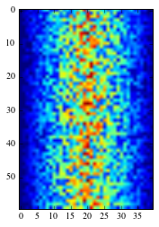

```python
%matplotlib inline
image = pyplot.imshow(data)
pyplot.show(image)
```

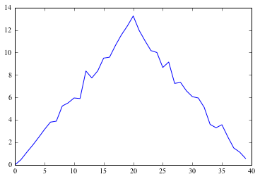

```python
ave_inflammation = data.mean(axis=0)
ave_plot = pyplot.plot(ave_inflammation)
pyplot.show(ave_plot)
```

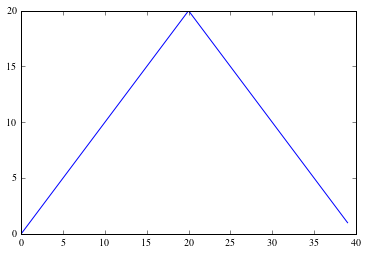

```python
max_plot = pyplot.plot(data.max(axis=0))
pyplot.show(max_plot)
```

## Putting all together in one nice piece of code

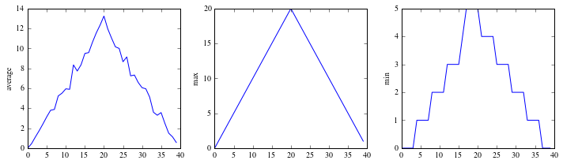

```python
import numpy as np
from matplotlib import pyplot as plt

data = np.loadtxt(fname="data/inflammation-01.csv", delimiter=",")

fig = plt.figure(figsize=(10.0, 3.0))

axes1 = fig.add_subplot(1, 3, 1)
axes2 = fig.add_subplot(1, 3, 2)
axes3 = fig.add_subplot(1, 3, 3)

axes1.set_ylabel('average')
axes1.plot(data.mean(axis=0))

axes2.set_ylabel('max')
axes2.plot(data.max(axis=0))

axes3.set_ylabel('min')
axes3.plot(data.min(axis=0))

fig.tight_layout()
plt.show(fig)
```

# For loops

```python
word = "lead"
```

```python
word
```

```
'lead'
```

```python
print word[0]
print word[1]
print word[2]
print word[3]
```

[output not shown]

```python
length = 0
for char in word:
    length = length + 1
    print char
    print "The number of letters ", length
```

```
l
The number of letters  1
e
The number of letters  2
a
The number of letters  3
d
The number of letters  4
```

```python
print char
```

```
d
```

```python
print length
```

```
4
```

```python
len(word)
```

```
4
```

```python
range(2, 8, 2)
```

```
[2, 4, 6]
```

```python
for number in range(1,4):
    print number
```

```
1
2
3
```

```python
result = 1
for times in range(3):
    result *= 5
print result
```

```
125
```

## Lists

```python
l = range(5)
```

```python
type(l)
```

```
list
```

```python
odd = [1, 3, 5]
```

```python
type(odd)
```

```
list
```

```python
print odd
```

```
[1, 3, 5]
```

```python
odd[1:]
```

```
[3, 5]
```

```python
odd[-2]
```

```
3
```

```python
names = ["Newton", "Darwin", "Tuinrg"]
```

```python
names[-2]
```

```
'Darwin'
```

```python
darwin = names[-2]
```

```python
print darwin
```

```
Darwin
```

```python
names[-1] = "Turing"
```

```python
names
```

```
['Newton', 'Darwin', 'Turing']
```

```python
darwin
```

```
'Darwin'
```

```python
darwin[0]
```

```
'D'
```

```python
darwin[0] = 'd'
```

```
---------------------------------------------------------------------------
TypeError                                 Traceback (most recent call last)
<ipython-input-92-1fe224db21d9> in <module>()
----> 1 darwin[0] = 'd'

TypeError: 'str' object does not support item assignment
```

```python
odd
```

```
[1, 3, 5]
```

```python
odd.append(7)
```

```python
odd
```

```
[1, 3, 5, 7]
```

```python
odd.reverse()
```

```python
odd
```

```
[7, 5, 3, 1]
```

```python
odd.append('john')
```

Lists can have different types of objects

```python
odd
```

```
[7, 5, 3, 1, 'john']
```

```python
type(odd[0])
```

```
int
```

```python
type(odd[-1])
```

```
str
```

### Using glob to get a list of files in our filesystem

Sorta `ls` in the shell, but storing the result into a Python list (nice!)

```python
import glob
```

```python
print glob.glob('*.ipynb')
```

```
['inflammation-analysis.ipynb']
```

```python
print glob.glob('./data/*.csv')
```

```
['./data/inflammation-01.csv', './data/inflammation-02.csv', './data/inflammation-03.csv', './data/inflammation-04.csv', './data/inflammation-05.csv', './data/inflammation-06.csv', './data/inflammation-07.csv', './data/inflammation-08.csv', './data/inflammation-09.csv', './data/inflammation-10.csv',…
```

```python
filenames = glob.glob("data/*csv")
```

```python
print filenames
```

```
['data/inflammation-01.csv', 'data/inflammation-02.csv', 'data/inflammation-03.csv', 'data/inflammation-04.csv', 'data/inflammation-05.csv', 'data/inflammation-06.csv', 'data/inflammation-07.csv', 'data/inflammation-08.csv', 'data/inflammation-09.csv', 'data/inflammation-10.csv', 'data/inflammation-…
```

## Putting all together: loop and analyze a bunch of files

```
Analyzing file:  data/inflammation-01.csv
```

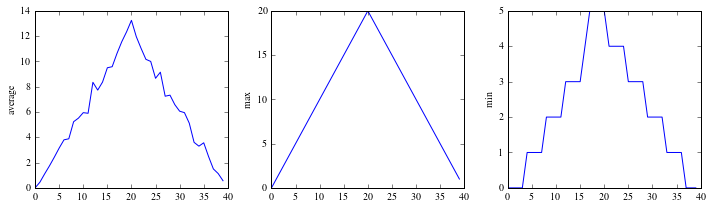

```
Analyzing file:  data/inflammation-02.csv
```

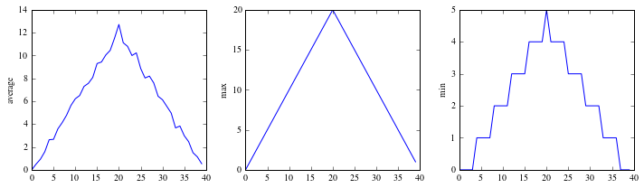

```
Analyzing file:  data/inflammation-03.csv
```

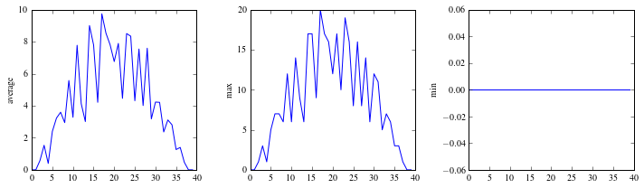

```python
for f in filenames[:3]:
    print "Analyzing file: ", f
    analyze_inflammation(f)
```

```python
def analyze(filename):
    """Analyze inflammation data and make plots
    """
    data = np.loadtxt(fname=filename, delimiter=",")

    fig = plt.figure(figsize=(10.0, 3.0))

    axes1 = fig.add_subplot(1, 3, 1)
    axes2 = fig.add_subplot(1, 3, 2)
    axes3 = fig.add_subplot(1, 3, 3)

    axes1.set_ylabel('average')
    axes1.plot(data.mean(axis=0))

    axes2.set_ylabel('max')
    axes2.plot(data.max(axis=0))

    axes3.set_ylabel('min')
    axes3.plot(data.min(axis=0))

    fig.tight_layout()

    plt.show(fig)
```

## Conditionals

```python
weight_kg = 20
```

```python
if weight_kg > 80:
    print "You're over 80 kg"
else:
    print "You're under 80 kg"
```

[output not shown]

```python
number = -3
```

```python
if (number >= 0):
    print "Positive"
else:
    print "Negative"
```

```
Negative
```

## Functions

```python
(80 - 32) * 5/9 + 273.15
```

```
299.15
```

```python
def fahr_to_kelvin(temp):
    return (temp - 32) * 5.0/9 + 273.15
```

```python
def kelvin_to_celsius(temp):
    '''Converts temperatures in Kelvin to Celsius

    More stuff
    '''
    result = temp - 273.15
    return result
```

```python
def farh_to_celsius(temp):
    kelvin = fahr_to_kelvin(temp)
    result = kelvin_to_celsius(kelvin)
    return result
```

```python
kelvin_to_celsius(fahr_to_kelvin(0))
```

[output not shown]

```python
fahr_to_kelvin(80)
```

[output not shown]

```python
temp_in_kelvin = fahr_to_kelvin(100)
```

```python
temp_in_kelvin
```

[output not shown]

> Be careful with dividing numbers

```python
10/9
```

```
1
```

```python
10.0/9
```

```
1.1111111111111112
```

```python
help(analyze)
```

```
Help on function analyze in module __main__:

analyze(filename)
    Analyze inflammation data and make plots
```

```python
help(np.loadtxt)
```

[output not shown]

[output cut: 30 more lines]

```
    array([[ 0.,  1.],
           [ 2.,  3.]])

    >>> d = StringIO("M 21 72\nF 35 58")
    >>> np.loadtxt(d, dtype={'names': ('gender', 'age', 'weight'),
    ...                      'formats': ('S1', 'i4', 'f4')})
    array([('M', 21, 72.0), ('F', 35, 58.0)],
          dtype=[('gender', '|S1'), ('age', '<i4'), ('weight', '<f4')])

    >>> c = StringIO("1,0,2\n3,0,4")
    >>> x, y = np.loadtxt(c, delimiter=',', usecols=(0, 2), unpack=True)
    >>> x
    array([ 1.,  3.])
    >>> y
    array([ 2.,  4.])
```